# RQ3 Step 2: Classifying next year’s rise or fall

Will a district’s consents rise or fall next year?

while True: learn(), Group 8, STAT462

2026-11-20

```r
source(file.path(proj_root, "R", "utils_data.R"))
source(file.path(proj_root, "R", "utils_models.R"))
source(file.path(proj_root, "R", "utils_classify.R"))
suppressPackageStartupMessages({
  library(knitr)
  library(MASS, exclude = "select")   # lda, qda (exclude 'select' so dplyr's select still works)
  library(class)                      # knn
  library(rpart)
  library(rpart.plot)
  library(glmnet)
  library(ranger)
})
N_CORES <- max(1, parallel::detectCores() - 1)
for (d in c(paths$fig_rq3, paths$tab_rq3, paths$models_rq3)) dir.create(d, showWarnings = FALSE, recursive = TRUE)

rq3   <- readRDS(file.path(paths$processed, "rq3_model_data.rds"))
dat   <- rq3$data
feats <- rq3$features
Y     <- "rise"
train <- dat |> filter(split == "train")     # feature years 1996-2016
test  <- dat |> filter(split == "test")      # feature years 2017-2024: used once, in section 6

# time-ordered folds: train on all years before a two-year block, validate on the block
folds <- make_time_folds(train$year, valid_blocks = list(2009:2010, 2011:2012, 2013:2014, 2015:2016))
sapply(folds, \(f) c(train_rows = length(f$train), valid_rows = length(f$valid)))
```

```
##            valid 2009-2010 valid 2011-2012 valid 2013-2014 valid 2015-2016
## train_rows             858             990            1122            1254
## valid_rows             132             132             132             132
```

# 1 Purpose and plan

Step 1 built 1,914 district-years (66 districts, feature years 1996–2024) with eleven features known at the end of each year, and the label “did new dwellings rise the following year?”. Here we fit classifiers, from the simplest to the most flexible, and compare them:

| Model | What it does | Tuned settings |
| --- | --- | --- |
| Baselines | majority class; “same direction as this year”; “opposite of this year” | none |
| Logistic regression | models the log-odds of a rise as a straight-line combination of the features | none |
| Lasso logistic regression | the same, with a penalty that shrinks weak coefficients to zero | penalty λ |
| LDA | assumes each class is a normal cloud with the same shape; draws a straight boundary | none |
| QDA | as LDA, but each class has its own shape; curved boundary | none |
| Classification tree | splits on thresholds into groups that are mostly rise or mostly fall | `cp`, `minbucket` |
| k-nearest neighbours | votes of the *k* most similar training district-years | *k* |
| Random forest | many trees on bootstrap samples, averaged | `mtry`, `min.node.size` |

The pitch named logistic regression, LDA and a tree. QDA and lasso are natural extensions of logistic regression and LDA; KNN and the random forest test whether a flexible model finds structure the linear ones miss.

**Ground rules (as in RQ1).** Tuning and model choice use time-ordered cross-validation on the training years only. The test years (2017–2024) are used once. Every model outputs a **probability** of a rise; a district-year is classified as “rise” when that probability is above 0.5.

# 2 How models are scored

| Metric | Meaning | Good |
| --- | --- | --- |
| Accuracy | share of district-years classified correctly | high |
| Sensitivity | share of actual rises predicted as rises | high |
| Specificity | share of actual falls predicted as falls | high |
| Balanced accuracy | mean of sensitivity and specificity; not fooled by predicting one class | high |
| **AUC** | probability that a random rise gets a higher predicted probability than a random fall; does not depend on the 0.5 threshold | 0.5 = guessing, 1 = perfect |
| Brier score | mean squared difference between the probability and the 0/1 outcome | low (0.25 = always saying 50%) |

Models are tuned and compared on **CV AUC**, because it measures how well the probabilities rank rises above falls without depending on a threshold.

# 3 Fitting and tuning the models

Each model is written as a function that fits on one data set and returns probabilities for another, so all models go through the same folds and metrics (`cv_tune_class()` in `R/utils_classify.R`).

```r
fml <- reformulate(feats, response = Y)
x_of <- function(df) as.matrix(df[feats])

fp_majority  <- function(tr, nw, p) rep(mean(tr[[Y]]), nrow(nw))
fp_same      <- function(tr, nw, p) as.numeric(nw$growth_1y > 0)     # rose this year -> rise next year
fp_opposite  <- function(tr, nw, p) as.numeric(nw$growth_1y <= 0)    # fell this year -> rise next year

fp_logistic  <- function(tr, nw, p) predict(glm(fml, data = tr, family = binomial), newdata = nw, type = "response")

lambda_grid <- 10^seq(-1, -5, length.out = 60)
fp_lasso <- function(tr, nw, p) {
  fit  <- glmnet(x_of(tr), tr[[Y]], family = "binomial", alpha = 1, lambda = lambda_grid)
  pred <- predict(fit, x_of(nw), type = "response")
  colnames(pred) <- fit$lambda
  pred
}

fp_lda <- function(tr, nw, p) predict(lda(fml, data = tr), newdata = nw)$posterior[, "1"]
fp_qda <- function(tr, nw, p) predict(qda(fml, data = tr), newdata = nw)$posterior[, "1"]

fp_tree <- function(tr, nw, p) {
  fit <- rpart(update(fml, factor(rise) ~ .), data = tr, method = "class",
               control = rpart.control(cp = p$cp, minbucket = p$minbucket, xval = 0))
  predict(fit, newdata = nw, type = "prob")[, "1"]
}

fp_knn <- function(tr, nw, p) {
  centre <- colMeans(x_of(tr)); spread <- apply(x_of(tr), 2, sd)     # scale with the TRAINING means and SDs
  xs_tr <- scale(x_of(tr), centre, spread); xs_nw <- scale(x_of(nw), centre, spread)
  set.seed(462)                                                       # knn breaks ties at random
  # use.all = FALSE: exactly k neighbours even when several are at the same distance
  pred <- knn(xs_tr, xs_nw, cl = factor(tr[[Y]]), k = p$k, prob = TRUE, use.all = FALSE)
  share_winner <- attr(pred, "prob")
  if_else(pred == "1", share_winner, 1 - share_winner)                # probability of a rise
}

fp_rf <- function(tr, nw, p) {
  fit <- ranger(update(fml, factor(rise) ~ .), data = tr, probability = TRUE, num.trees = 500,
                mtry = p$mtry, min.node.size = p$min.node.size, num.threads = N_CORES, seed = 462)
  predict(fit, data = nw)$predictions[, "1"]
}
```

```r
tune <- function(fp, grid = NULL, inner = NULL) timed(cv_tune_class(fp, grid, train, folds, Y, inner))
res <- list(
  "Majority class"          = tune(fp_majority),
  "Same as this year"       = tune(fp_same),
  "Opposite of this year"   = tune(fp_opposite),
  "Logistic regression"     = tune(fp_logistic),
  "Lasso logistic"          = tune(fp_lasso, inner = "lambda"),
  "LDA"                     = tune(fp_lda),
  "QDA"                     = tune(fp_qda),
  "Classification tree"     = tune(fp_tree, expand_grid(cp = c(0.0005, 0.001, 0.002, 0.005, 0.01, 0.02, 0.05),
                                                        minbucket = c(10, 30, 60))),
  "k-nearest neighbours"    = tune(fp_knn, tibble(k = c(5, 11, 21, 41, 81, 121, 201, 301, 451))),
  "Random forest"           = tune(fp_rf, expand_grid(mtry = c(2, 3, 5, 8), min.node.size = c(5, 20, 50)))
)
```

```r
model_order <- names(res)
cv_all <- imap_dfr(res, summarise_class_tuning) |>
  mutate(model = factor(model, levels = model_order))
# later cached chunks depend on the tuning results: re-run them whenever these change
knitr::opts_chunk$set(cache.extra = list(file_md5, rlang::hash(cv_all)))
save_tab(cv_all, "t03_cv_results", dir = paths$tab_rq3) |>
  select(model, best_settings, cv_auc, cv_auc_se, cv_accuracy, cv_balanced_accuracy, cv_brier) |>
  kable(digits = 3, caption = "Cross-validation (validation years 2009–2016), best setting of each model")
```

Cross-validation (validation years 2009–2016), best setting of each model

| model | best_settings | cv_auc | cv_auc_se | cv_accuracy | cv_balanced_accuracy | cv_brier |
| --- | --- | --- | --- | --- | --- | --- |
| Majority class | (none) | 0.500 | 0.000 | 0.513 | 0.500 | 0.249 |
| Same as this year | (none) | 0.452 | 0.022 | 0.479 | 0.452 | 0.521 |
| Opposite of this year | (none) | 0.548 | 0.022 | 0.521 | 0.548 | 0.479 |
| Logistic regression | (none) | 0.676 | 0.034 | 0.653 | 0.586 | 0.216 |
| Lasso logistic | lambda = 3.49e-05 | 0.677 | 0.034 | 0.653 | 0.586 | 0.216 |
| LDA | (none) | 0.675 | 0.033 | 0.655 | 0.586 | 0.216 |
| QDA | (none) | 0.649 | 0.033 | 0.631 | 0.608 | 0.265 |
| Classification tree | cp = 5e-04, minbucket = 30 | 0.599 | 0.043 | 0.587 | 0.567 | 0.268 |
| k-nearest neighbours | k = 301 | 0.626 | 0.048 | 0.578 | 0.534 | 0.238 |
| Random forest | mtry = 2, min.node.size = 50 | 0.645 | 0.048 | 0.602 | 0.582 | 0.230 |

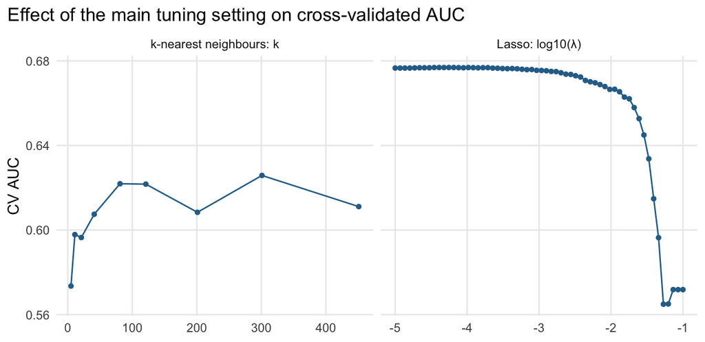

```r
p_tune <- bind_rows(
  res[["k-nearest neighbours"]]$summary |> transmute(model = "k-nearest neighbours: k", x = k, cv_auc),
  res[["Lasso logistic"]]$summary |> transmute(model = "Lasso: log10(λ)", x = log10(lambda), cv_auc)) |>
  ggplot(aes(x, cv_auc)) + geom_line(colour = "#2a6f97") + geom_point(colour = "#2a6f97", size = 1.2) +
  facet_wrap(~model, scales = "free_x") +
  labs(title = "Effect of the main tuning setting on cross-validated AUC", x = NULL, y = "CV AUC")
save_fig(p_tune, "fig03_tuning_curves", dir = paths$fig_rq3, height = 3.4, width = 8)
```

**Observation.** * **The baselines are weak.** “Same direction as this year” is *worse* than guessing (CV AUC 0.45), and “opposite of this year” is only slightly better (0.55). A district that rose this year is a little more likely to fall next year than to rise again, but this mean reversion is weak. * **Logistic regression, lasso and LDA are joint best** (CV AUC about 0.68), and almost identical. The lasso’s best penalty is so small (λ ≈ 0.00003) that it is effectively plain logistic regression: no feature is worth dropping. * **The flexible models do not help.** The random forest (0.645), QDA (0.649), KNN (0.626) and the tree (0.60) are all below the linear models. KNN’s best *k* is very large (301 neighbours out of about 1,000 training rows), so it wants to average over a third of the data, not over close neighbours. The forest prefers its most restricted settings (`mtry` = 2, large leaves). Both point to a weak, mostly linear signal with little local or interaction structure for flexible models to exploit. * The tree’s best `cp` is the smallest value tried, which means a large tree. Yet its CV AUC is almost the same at every `cp` (about 0.60), so a single tree is unstable here whatever its size.

## 3.1 Choosing a model

As in RQ1, we take the best CV AUC, subtract one standard error, and choose the **simplest** model above that line. Models are ordered from simplest to most flexible as in the table above (baselines are not candidates).

```r
candidates <- cv_all |> filter(!model %in% c("Majority class", "Same as this year", "Opposite of this year"))
best_row  <- candidates |> slice_max(cv_auc, n = 1)
threshold <- best_row$cv_auc - best_row$cv_auc_se
chosen <- candidates |> filter(cv_auc >= threshold) |> arrange(model) |> slice(1)
candidates |> mutate(within_1se = cv_auc >= threshold) |> select(model, cv_auc, cv_auc_se, within_1se) |>
  kable(digits = 3)
```

| model | cv_auc | cv_auc_se | within_1se |
| --- | --- | --- | --- |
| Logistic regression | 0.676 | 0.034 | TRUE |
| Lasso logistic | 0.677 | 0.034 | TRUE |
| LDA | 0.675 | 0.033 | TRUE |
| QDA | 0.649 | 0.033 | TRUE |
| Classification tree | 0.599 | 0.043 | FALSE |
| k-nearest neighbours | 0.626 | 0.048 | FALSE |
| Random forest | 0.645 | 0.048 | TRUE |

```r
c(best = as.character(best_row$model), threshold = round(threshold, 3), chosen = as.character(chosen$model))
```

```
##                  best             threshold                chosen
##      "Lasso logistic"               "0.643" "Logistic regression"
```

# 4 Test-set evaluation (2017–2024)

Each model is refitted at its tuned settings on all training years and scored once on the 528 test district-years.

```r
fps <- list("Majority class" = fp_majority, "Same as this year" = fp_same, "Opposite of this year" = fp_opposite,
            "Logistic regression" = fp_logistic, "Lasso logistic" = fp_lasso, "LDA" = fp_lda, "QDA" = fp_qda,
            "Classification tree" = fp_tree, "k-nearest neighbours" = fp_knn, "Random forest" = fp_rf)
test_prob <- imap_dfr(fps, function(fp, m) {
  best <- as.list(res[[m]]$best)
  p <- as.matrix(fp(train, test, best))
  if (m == "Lasso logistic") p <- p[, which.min(abs(as.numeric(colnames(p)) - best$lambda)), drop = FALSE]
  tibble(model = m, row = seq_len(nrow(test)), prob = as.numeric(p))
})
```

```r
test_long <- test_prob |>
  left_join(test |> mutate(row = row_number()) |> select(row, ta, year, rise, nat_rise_next), by = "row")
test_res <- test_long |>
  group_by(model) |>
  summarise(class_metrics(rise, prob), .groups = "drop") |>
  left_join(cv_all |> select(model, cv_auc) |> mutate(model = as.character(model)), by = "model") |>
  mutate(model = factor(model, levels = model_order)) |>
  arrange(model)
tv <- function(m, col = "auc") test_res[[col]][test_res$model == m]
save_tab(test_res, "t04_test_results", dir = paths$tab_rq3) |>
  kable(digits = 3, caption = "Test years 2017–2024 (outcomes 2018–2025): every model at its tuned settings")
```

Test years 2017–2024 (outcomes 2018–2025): every model at its tuned settings

| model | accuracy | sensitivity | specificity | balanced_accuracy | auc | brier | log_loss | cv_auc |
| --- | --- | --- | --- | --- | --- | --- | --- | --- |
| Majority class | 0.477 | 1.000 | 0.000 | 0.500 | 0.500 | 0.253 | 0.698 | 0.500 |
| Same as this year | 0.470 | 0.452 | 0.486 | 0.469 | 0.469 | 0.530 | 7.326 | 0.452 |
| Opposite of this year | 0.530 | 0.548 | 0.514 | 0.531 | 0.531 | 0.470 | 6.489 | 0.548 |
| Logistic regression | 0.583 | 0.659 | 0.514 | 0.587 | 0.628 | 0.240 | 0.674 | 0.676 |
| Lasso logistic | 0.585 | 0.663 | 0.514 | 0.589 | 0.629 | 0.240 | 0.674 | 0.677 |
| LDA | 0.580 | 0.675 | 0.493 | 0.584 | 0.629 | 0.241 | 0.674 | 0.675 |
| QDA | 0.549 | 0.706 | 0.406 | 0.556 | 0.609 | 0.287 | 0.843 | 0.649 |
| Classification tree | 0.530 | 0.468 | 0.587 | 0.528 | 0.516 | 0.288 | 0.783 | 0.599 |
| k-nearest neighbours | 0.564 | 0.754 | 0.391 | 0.573 | 0.631 | 0.243 | 0.679 | 0.626 |
| Random forest | 0.580 | 0.567 | 0.591 | 0.579 | 0.619 | 0.240 | 0.673 | 0.645 |

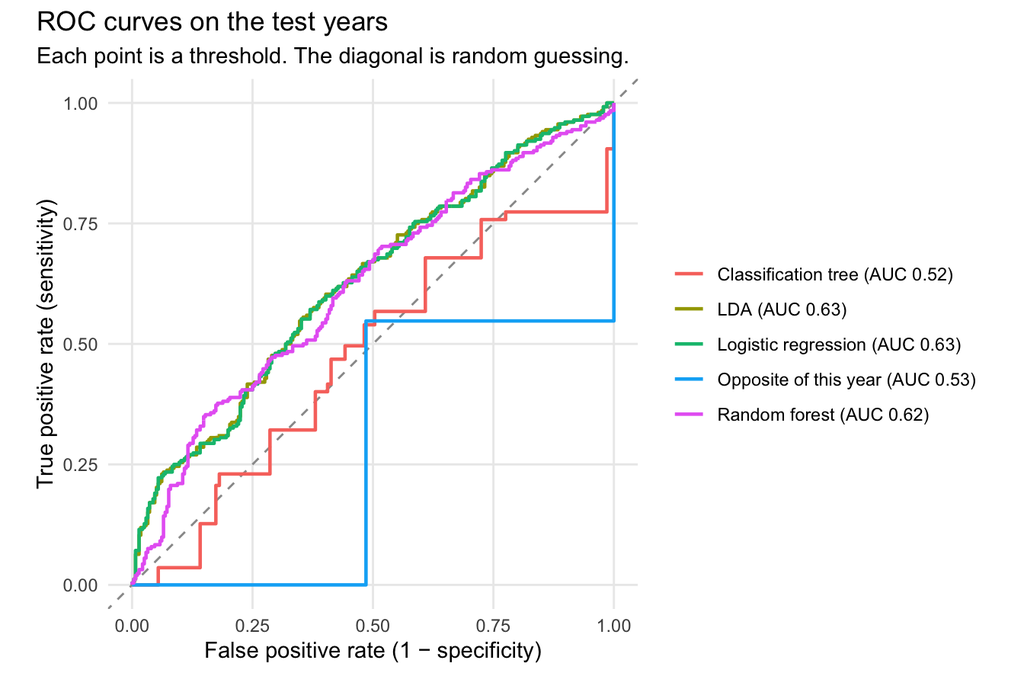

```r
roc_models <- c("Logistic regression", "LDA", "Classification tree", "Random forest", "Opposite of this year")
roc_df <- test_long |> filter(model %in% roc_models) |>
  group_by(model) |> group_modify(\(d, k) roc_points(d$rise, d$prob)) |> ungroup() |>
  left_join(test_res |> transmute(model = as.character(model), auc), by = "model") |>
  mutate(label = sprintf("%s (AUC %.2f)", model, auc))
p_roc <- ggplot(roc_df, aes(fpr, tpr, colour = label)) +
  geom_abline(linetype = 2, colour = "grey60") +
  geom_step(linewidth = 0.8) +
  coord_equal() +
  labs(title = "ROC curves on the test years",
       subtitle = "Each point is a threshold. The diagonal is random guessing.",
       x = "False positive rate (1 − specificity)", y = "True positive rate (sensitivity)", colour = NULL) +
  theme(legend.position = "right")
save_fig(p_roc, "fig04_roc_test", dir = paths$fig_rq3, height = 4.6, width = 8)
```

```r
conf <- test_long |> filter(model == as.character(chosen$model)) |>
  mutate(predicted = if_else(prob > 0.5, "rise", "fall"), actual = if_else(rise == 1, "rise", "fall"))
table(Predicted = conf$predicted, Actual = conf$actual)
```

```
##          Actual
## Predicted fall rise
##      fall  142   86
##      rise  134  166
```

# 5 Where the model succeeds and fails: year by year

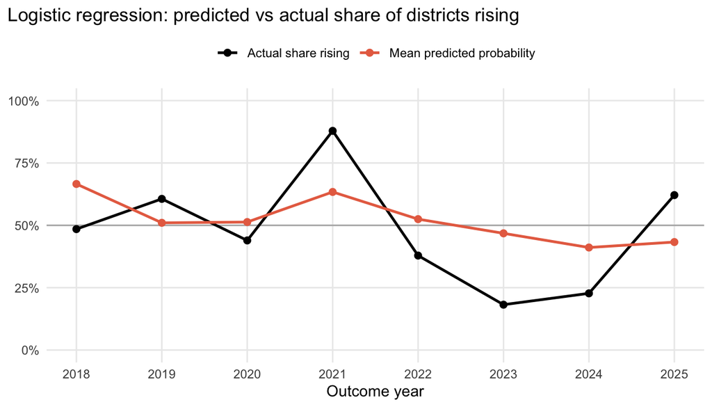

```r
year_df <- test_long |> filter(model == as.character(chosen$model)) |>
  group_by(year) |>
  summarise(actual_share = mean(rise), predicted_share = mean(prob > 0.5), mean_prob = mean(prob),
            accuracy = mean((prob > 0.5) == rise), within_year_auc = auc(rise, prob), .groups = "drop")

p_by_year <- year_df |>
  pivot_longer(c(actual_share, mean_prob), names_to = "series") |>
  mutate(series = recode(series, actual_share = "Actual share rising", mean_prob = "Mean predicted probability")) |>
  ggplot(aes(year + 1, value, colour = series)) +
  geom_hline(yintercept = 0.5, colour = "grey70") +
  geom_line(linewidth = 0.9) + geom_point(size = 2) +
  scale_colour_manual(values = c("Actual share rising" = "black", "Mean predicted probability" = "#e76f51")) +
  scale_y_continuous(labels = scales::percent, limits = c(0, 1)) +
  scale_x_continuous(breaks = 2018:2025) +
  labs(title = paste0(chosen$model, ": predicted vs actual share of districts rising"),
       x = "Outcome year", y = NULL, colour = NULL) +
  theme(legend.position = "top")
save_fig(p_by_year, "fig05_test_by_year", dir = paths$fig_rq3, height = 4)
```

```r
year_df |> mutate(year = year + 1) |> rename(outcome_year = year) |> kable(digits = 3)
```

| outcome_year | actual_share | predicted_share | mean_prob | accuracy | within_year_auc |
| --- | --- | --- | --- | --- | --- |
| 2018 | 0.485 | 0.924 | 0.666 | 0.470 | 0.529 |
| 2019 | 0.606 | 0.576 | 0.510 | 0.606 | 0.627 |
| 2020 | 0.439 | 0.621 | 0.513 | 0.545 | 0.547 |
| 2021 | 0.879 | 0.818 | 0.634 | 0.758 | 0.634 |
| 2022 | 0.379 | 0.591 | 0.525 | 0.485 | 0.532 |
| 2023 | 0.182 | 0.455 | 0.468 | 0.606 | 0.677 |
| 2024 | 0.227 | 0.288 | 0.411 | 0.606 | 0.493 |
| 2025 | 0.621 | 0.273 | 0.433 | 0.591 | 0.689 |

```r
c(mean_within_year_auc = mean(year_df$within_year_auc))
```

```
## mean_within_year_auc
##            0.5909734
```

**Observation.** This figure shows why RQ3 is hard.

- **The model follows the national direction only weakly.** It predicted more rises than falls in 2021 (correct), but its average probability (63%) was far below the 88% that actually rose. In 2023 and 2024 it leaned towards falls (47% and 41%) when only 18–23% of districts rose.
- **It misses turning points.** For 2018 it predicted rises for 92% of districts, when only half rose. For 2025 it predicted mostly falls (27% predicted to rise), and 62% rose. The national features describe where the cycle *is*, but not reliably when it will *turn*.
- **Within a year, ranking is weak but real.** In each year separately, the AUC averages 0.59. Given the national direction, the model can only slightly pick out which districts are more likely to rise.
- Accuracy by year ranges from 47% to 76%. It is best in years when most districts move the same way as the model expects, and worst at turning points.

# 6 What drives the predictions?

## 6.1 Logistic regression: odds ratios

Logistic regression models the **log-odds** of a rise:

$$\log\frac{P(\text{rise})}{1 - P(\text{rise})} = \beta_0 + \beta_1 x_1 +
\dots + \beta_{11} x_{11}.$$

The **odds** are P(rise) ÷ P(fall): odds of 1 mean 50:50, odds of 2 mean a rise is twice as likely as a fall. With standardised features, e^β is the **odds ratio** for a one-standard-deviation increase in that feature, holding the others fixed. An odds ratio above 1 makes a rise more likely, below 1 less likely.

```r
train_std <- train |> mutate(across(all_of(feats), \(x) as.numeric(scale(x))))
logit_std <- glm(fml, data = train_std, family = binomial)
or_tab <- summary(logit_std)$coefficients[-1, ] |>
  as_tibble(rownames = "feature") |>
  transmute(feature, estimate = Estimate, se = `Std. Error`, p_value = `Pr(>|z|)`,
            odds_ratio = exp(estimate), lower = exp(estimate - 1.96 * se), upper = exp(estimate + 1.96 * se)) |>
  arrange(desc(abs(estimate)))
save_tab(or_tab, "t05_odds_ratios", dir = paths$tab_rq3) |>
  kable(digits = 3, caption = "Logistic regression (training years): odds ratio for a 1-SD increase, with 95% interval")
```

Logistic regression (training years): odds ratio for a 1-SD increase, with 95% interval

| feature | estimate | se | p_value | odds_ratio | lower | upper |
| --- | --- | --- | --- | --- | --- | --- |
| nat_dev_5y | 0.603 | 0.092 | 0.000 | 1.828 | 1.525 | 2.190 |
| nat_h2_vs_h1 | 0.528 | 0.071 | 0.000 | 1.696 | 1.476 | 1.949 |
| nat_growth_1y | -0.521 | 0.096 | 0.000 | 0.594 | 0.492 | 0.717 |
| multiunit_share | -0.290 | 0.067 | 0.000 | 0.748 | 0.657 | 0.853 |
| alt_growth | 0.239 | 0.063 | 0.000 | 1.270 | 1.123 | 1.437 |
| h2_vs_h1 | 0.233 | 0.063 | 0.000 | 1.263 | 1.116 | 1.429 |
| dwell_per_1000 | -0.205 | 0.076 | 0.007 | 0.815 | 0.701 | 0.946 |
| dev_5y | -0.195 | 0.092 | 0.035 | 0.823 | 0.687 | 0.987 |
| log_dwellings | 0.151 | 0.076 | 0.048 | 1.162 | 1.001 | 1.350 |
| growth_1y | -0.135 | 0.087 | 0.121 | 0.874 | 0.737 | 1.036 |
| nonres_growth | 0.036 | 0.061 | 0.554 | 1.037 | 0.920 | 1.168 |

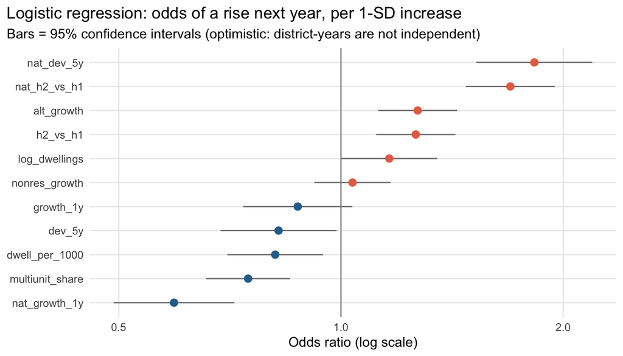

```r
p_or <- ggplot(or_tab, aes(odds_ratio, fct_reorder(feature, odds_ratio))) +
  geom_vline(xintercept = 1, colour = "grey60") +
  geom_linerange(aes(xmin = lower, xmax = upper), colour = "grey50") +
  geom_point(aes(colour = odds_ratio > 1), size = 2.5, show.legend = FALSE) +
  scale_colour_manual(values = c(`TRUE` = "#e76f51", `FALSE` = "#2a6f97")) +
  scale_x_log10() +
  labs(title = "Logistic regression: odds of a rise next year, per 1-SD increase",
       subtitle = "Bars = 95% confidence intervals (optimistic: district-years are not independent)",
       x = "Odds ratio (log scale)", y = NULL)
save_fig(p_or, "fig06_odds_ratios", dir = paths$fig_rq3, height = 4)
```

**Observation.** The three **national** features have the largest effects:

- **`nat_dev_5y`** (odds ratio about 1.8 per SD): when New Zealand is building above its five-year average, districts are more likely to rise again. The national cycle has momentum over one year.
- **`nat_h2_vs_h1`** (about 1.7): a strong second half of the year nationally points to a rise next year.
- **`nat_growth_1y`** (about 0.6): *holding the other two fixed*, a big national jump this year makes a rise next year less likely. Together with the first two, the model reads “high and still building momentum” as rising, and “a sudden jump” as likely to cool.

District features have smaller effects:

- a higher **multi-unit share** lowers the odds (0.75), because apartment and townhouse projects come in lumps;
- stronger **alteration growth** (1.27) and a stronger **second half** in the district (1.26) raise them;
- higher **building intensity** (0.82) and being **above the district’s own five-year average** (0.82) lower them (mean reversion);
- non-residential growth has no detectable effect.

The confidence intervals assume independent rows. District-years in the same year are strongly linked through the national cycle, so the intervals are too narrow. We read the odds ratios as directions and rough sizes, not as precise tests.

## 6.2 LDA: the discriminant direction

LDA finds the single combination of features along which the two classes are furthest apart, relative to their spread. Its coefficients (`scaling`) give that direction. On standardised features they are comparable in size.

```r
lda_std <- lda(fml, data = train_std)
tibble(feature = rownames(lda_std$scaling), LD1 = lda_std$scaling[, 1]) |>
  left_join(or_tab |> select(feature, logistic_coef = estimate), by = "feature") |>
  arrange(desc(abs(LD1))) |> kable(digits = 3, caption = "LDA coefficients vs logistic coefficients (standardised features)")
```

LDA coefficients vs logistic coefficients (standardised features)

| feature | LD1 | logistic_coef |
| --- | --- | --- |
| nat_dev_5y | 0.787 | 0.603 |
| nat_h2_vs_h1 | 0.717 | 0.528 |
| nat_growth_1y | -0.702 | -0.521 |
| multiunit_share | -0.368 | -0.290 |
| alt_growth | 0.315 | 0.239 |
| h2_vs_h1 | 0.291 | 0.233 |
| dwell_per_1000 | -0.256 | -0.205 |
| dev_5y | -0.253 | -0.195 |
| log_dwellings | 0.189 | 0.151 |
| growth_1y | -0.166 | -0.135 |
| nonres_growth | 0.047 | 0.036 |

```r
lda_std$prior
```

```
##        0        1
## 0.466811 0.533189
```

**Observation.** The LDA coefficients are almost exactly proportional to the logistic coefficients (each about 1.3 times larger) and rank the features in the same order. This is expected. With two classes, both methods produce a straight-line boundary in the features, and they differ only in how they estimate it:

- **logistic regression** maximises the likelihood of the observed rises and falls directly;
- **LDA** assumes each class is a normal cloud with the same covariance matrix and applies Bayes’ rule.

When the assumptions roughly hold, or the signal is weak, they agree, which is why their test results are almost identical. QDA drops the equal-covariance assumption and fits a curved boundary, but with a weak signal the extra flexibility mostly adds noise (lower AUC, worse Brier score). The priors (47% fall, 53% rise) are the class shares in the training data.

## 6.3 Classification tree

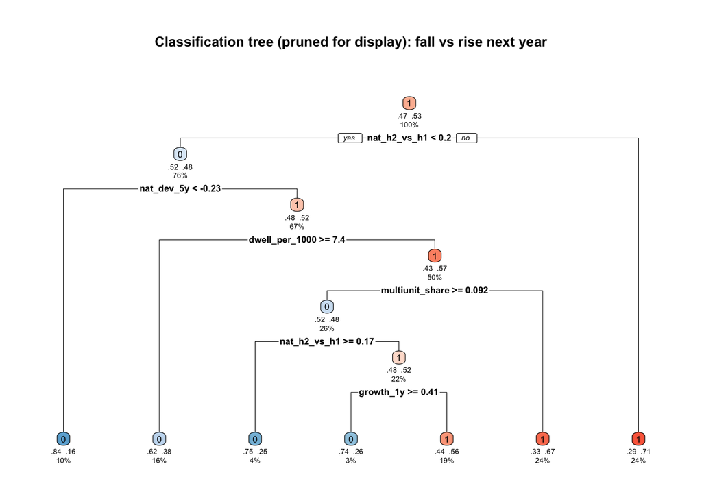

```r
bt <- res[["Classification tree"]]$best
tree_fit <- rpart(update(fml, factor(rise) ~ .), data = train, method = "class",
                  control = rpart.control(cp = 0.02, minbucket = bt$minbucket, xval = 0))   # pruned harder so it can be read
draw_tree <- function() rpart.plot(tree_fit, type = 2, extra = 104, under = TRUE, roundint = FALSE,
                                   box.palette = "BuRd", main = "Classification tree (pruned for display): fall vs rise next year")
png(file.path(paths$fig_rq3, "fig07_tree.png"), width = 10, height = 5.5, units = "in", res = 200)
draw_tree(); invisible(dev.off())
draw_tree()
```

The splits tell the same story as the logistic regression. But a single tree turns these weak signals into hard thresholds that change a lot from sample to sample, which is why its test AUC is close to 0.5.

# 7 A check: removing the national cycle

Most of the difficulty comes from the national cycle. Following RQ1’s relative-cost idea, we also try a **relative** label: did the district’s new dwellings grow **faster than the rest of New Zealand’s** next year? This removes the national direction from the label, so only district differences are left to predict. We fit logistic regression on the district features only (the national ones are the same for every district in a year and cannot help).

```r
add_relative <- function(df) {
  df |> group_by(year) |>
    mutate(tot = sum(dwellings), next_tot = sum(next_dwellings)) |> ungroup() |>
    mutate(g_district = log((next_dwellings + 1) / (dwellings + 1)),
           g_rest     = log((next_tot - next_dwellings) / (tot - dwellings)),
           outperform = as.integer(g_district > g_rest))
}
dat_rel <- add_relative(dat)
district_feats <- setdiff(feats, c("nat_growth_1y", "nat_dev_5y", "nat_h2_vs_h1"))
fml_rel <- reformulate(district_feats, "outperform")
rel_fit <- glm(fml_rel, data = dat_rel |> filter(split == "train"), family = binomial)
rel_test <- dat_rel |> filter(split == "test")
rel_prob <- predict(rel_fit, rel_test, type = "response")
bind_rows(class_metrics(rel_test$outperform, rel_prob) |> mutate(model = "Logistic, relative label"),
          class_metrics(rel_test$outperform, rep(mean(dat_rel$outperform[dat_rel$split == "train"]), nrow(rel_test))) |>
            mutate(model = "Majority class, relative label")) |>
  select(model, accuracy, balanced_accuracy, auc, brier) |> kable(digits = 3)
```

| model | accuracy | balanced_accuracy | auc | brier |
| --- | --- | --- | --- | --- |
| Logistic, relative label | 0.557 | 0.552 | 0.553 | 0.255 |
| Majority class, relative label | 0.460 | 0.500 | 0.500 | 0.251 |

**Observation.** Removing the national cycle does **not** make the problem easier. With the relative label (“did the district beat the rest of NZ?”), logistic regression on the district features reaches AUC 0.55, lower than for the original label. District features carry only a small amount of information about next year, whichever way the label is defined. The national features add the most, but they can’t fully predict the national turning points.

# 8 Answer to RQ3

**Question.** Will a district’s consents rise or fall next year?

**Answer.** Only slightly better than a coin toss, using the consents data alone.

**Limitations.**

- The consents data contain no economic drivers: interest rates, migration, house prices and credit conditions are what turn the national cycle. Adding them would be the most promising next step.
- District-years in the same year are not independent, so the odds-ratio intervals are optimistic.
- Small districts have noisy year-to-year counts, which no model can predict.

| Model | Test accuracy | Test AUC | Note |
| --- | --- | --- | --- |
| Always “rise” (majority class) | 48% | 0.50 | baseline |
| Opposite of this year | 53% | 0.53 | best simple rule |
| **Logistic regression** | **58%** | **0.63** | chosen (simplest within 1 SE) |
| LDA | 58% | 0.63 | same boundary as logistic |
| Random forest | 58% | 0.62 | no gain from flexibility |
| Classification tree | 53% | 0.52 | unstable |

# 9 Save

```r
final_fit <- glm(fml, data = dat, family = binomial)    # chosen model refitted on all years, for later use
saveRDS(list(cv = cv_all, test = test_res, chosen = chosen, test_predictions = test_long,
             odds_ratios = or_tab, by_year = year_df,
             final_logistic = final_fit, features = feats,
             latest = dat |> filter(year == max(year))),
        file.path(paths$models_rq3, "rq3_results.rds"))
list.files(paths$models_rq3)
```

```
## [1] "rq3_results.rds"
```

# 10 Appendix: helper functions

This notebook uses helper functions from `R/utils_data.R`, `R/utils_models.R` and `R/utils_classify.R`, printed here so the document is complete on its own.

```r
# =============================================================================
# R/utils_data.R
# Shared helpers for reading and reshaping Stats NZ data.
# Source this from any Rmd after the project root has been set:
#   source(file.path(proj_root, "R", "utils_data.R"))
# =============================================================================

suppressPackageStartupMessages({
  library(data.table)
  library(tidyverse)
})

# ---- Paths (all relative to the project root) -------------------------------
paths <- list(
  raw_extracted = "data/raw/extracted",
  raw_cgpi      = "data/raw/external/cgpi",
  reference     = "data/reference",
  processed     = "data/processed",
  fig_rq1       = "outputs/figures/rq1",
  tab_rq1       = "outputs/tables/rq1",
  fig_rq2       = "outputs/figures/rq2",
  tab_rq2       = "outputs/tables/rq2"
)

# ---- Reading Stats NZ "Infoshare" long-format CSVs --------------------------
# Every Infoshare file has one row per (series x period). We read only the
# columns that carry information and give them short working names.
#
# Notes
# * `Period` MUST be read as text: as a number, "2025.10" becomes 2025.1,
#   which is indistinguishable from January.
# * integer64 is turned off so that large dollar values come back as doubles
#   (integer64 silently overflows on division).
read_infoshare <- function(file,
                           dir = paths$raw_extracted,
                           keep_status = FALSE) {
  cols <- c("Series_reference", "Period", "Data_value",
            "Series_title_1", "Series_title_2",
            "Series_title_3", "Series_title_4", "Series_title_5")
  if (keep_status) cols <- c(cols, "Status")

  dt <- fread(file.path(dir, file),
              select      = cols,
              colClasses  = list(character = "Period"),
              integer64   = "double",
              na.strings  = c("", "NA"),
              showProgress = FALSE)

  as_tibble(dt) |>
    rename(series  = Series_reference,
           period  = Period,
           value   = Data_value,
           area    = Series_title_1,
           btype   = Series_title_2,
           work    = Series_title_3,
           measure = Series_title_4,
           adjust  = Series_title_5)   # Actual / Seasonally adjusted / Trend (regional files only)
}

# ---- Period helpers ----------------------------------------------------------
# "YYYY.MM" -> integer year / month / calendar quarter
period_year    <- function(p) as.integer(substr(p, 1, 4))
period_month   <- function(p) as.integer(substr(p, 6, 7))
month_quarter  <- function(m) (m - 1L) %/% 3L + 1L

# Label like "2019Q3"
yq_label <- function(year, quarter) paste0(year, "Q", quarter)

# Sequential quarter index (1990Q1 = 1) - handy as a numeric time trend
yq_index <- function(year, quarter) (year - 1990L) * 4L + quarter

# ---- GST ---------------------------------------------------------------------
# Consent values are GST-inclusive. GST was 12.5% from 1 Jul 1989 to
# 30 Sep 2010 and 15% from 1 Oct 2010. Every month in our data is >= 1990,
# so only these two rates apply. Quarter boundaries line up with the change
# (2010Q4 starts on 1 Oct 2010), so a quarter-level rule is exact.
gst_rate <- function(year, quarter) {
  if_else(yq_index(year, quarter) >= yq_index(2010L, 4L), 0.15, 0.125)
}

# ---- Small display helpers ---------------------------------------------------
fmt_int <- function(x) format(round(x), big.mark = ",", scientific = FALSE)
fmt_dol <- function(x) paste0("$", fmt_int(x))
fmt_pct <- function(x, d = 1) paste0(format(round(100 * x, d), nsmall = d), "%")

# ---- Figures -----------------------------------------------------------------
theme_set(theme_minimal(base_size = 11) +
            theme(plot.title.position = "plot",
                  panel.grid.minor = element_blank()))

# Save a ggplot as PNG (for the report) and return it (so it also shows in the Rmd)
save_fig <- function(p, name, dir = paths$fig_rq1, width = 7, height = 4.2) {
  dir.create(dir, recursive = TRUE, showWarnings = FALSE)
  ggsave(file.path(dir, paste0(name, ".png")), p,
         width = width, height = height, dpi = 200, bg = "white")
  p
}

# Save a table as CSV (for the report) and return it
save_tab <- function(df, name, dir = paths$tab_rq1) {
  dir.create(dir, recursive = TRUE, showWarnings = FALSE)
  write_csv(df, file.path(dir, paste0(name, ".csv")))
  df
}
```

```r
# =============================================================================
# R/utils_models.R
# Shared helpers for fitting, tuning and comparing models (Step 3 onwards).
# Source AFTER utils_data.R:
#   source(file.path(proj_root, "R", "utils_data.R"))
#   source(file.path(proj_root, "R", "utils_models.R"))
#
# The idea: every model is written as ONE function
#     fit_predict(train_df, new_df, params)  ->  predictions for new_df
# and the same tuning / scoring code is used for all of them. That way every
# model is judged on exactly the same folds with exactly the same metrics.
# =============================================================================

paths$models_rq1 <- "outputs/models/rq1"

# ---- Metrics -----------------------------------------------------------------
# obs, pred: numeric vectors on the LOG scale.
#   rmse  root mean squared error   (penalises big misses more)
#   mae   mean absolute error       (typical miss)
#   r2    1 - SSE / SST             (share of variance explained, on these rows)
# On the log scale an error of 0.10 is roughly a 10% miss in $/m².
reg_metrics <- function(obs, pred) {
  e <- pred - obs
  tibble(rmse = sqrt(mean(e^2)),
         mae  = mean(abs(e)),
         r2   = 1 - sum(e^2) / sum((obs - mean(obs))^2))
}

# MAPE on the dollar scale: mean |predicted - actual| / actual
mape <- function(obs_dollars, pred_dollars) mean(abs(pred_dollars - obs_dollars) / obs_dollars)

# ---- Time-ordered cross-validation folds ------------------------------------
# "Forward-chaining" (rolling-origin) CV: each fold trains on all years BEFORE a
# validation block and validates on that block. This mimics the real task
# (learn from the past, predict the future) and never lets a model peek ahead.
#   years        : the year of every training row
#   valid_blocks : list of year vectors, one per fold
# Returns a named list of folds, each with $train and $valid row numbers.
make_time_folds <- function(years,
                            valid_blocks = list(2012:2013, 2014:2015, 2016:2017, 2018:2019)) {
  folds <- lapply(valid_blocks, function(b)
    list(train = which(years < min(b)), valid = which(years %in% b)))
  names(folds) <- vapply(valid_blocks, function(b) paste0("valid ", min(b), "-", max(b)), "")
  folds
}

# ---- Generic tuner -----------------------------------------------------------
# fit_predict(train_df, new_df, params) must return either
#   * a numeric vector (one prediction per row of new_df), or
#   * a matrix with one column per value of an "inner" setting that one fit can
#     produce for free (lambda for glmnet, number of rounds for xgboost). The
#     column names hold that setting's value and `inner` names it.
#     The values are rounded to 6 significant figures before grouping: going
#     through column names (text) can change the last digits, and then the
#     same lambda would not match across folds.
# grid: data frame, one row per combination of settings to try.
# Returns list(folds = per-fold scores, summary = mean score per setting,
#              best = the setting with the lowest mean RMSE).
cv_tune <- function(fit_predict, grid, data, folds, response, inner = NULL) {
  grid <- as_tibble(grid)
  if (nrow(grid) == 0) grid <- tibble(.dummy = 1)

  per_fold <- map_dfr(seq_len(nrow(grid)), function(g) {
    params <- as.list(grid[g, , drop = FALSE])
    map_dfr(names(folds), function(fn) {
      f    <- folds[[fn]]
      pred <- fit_predict(data[f$train, ], data[f$valid, ], params)
      pred <- as.matrix(pred)
      if (is.null(colnames(pred))) colnames(pred) <- "0"
      obs  <- data[[response]][f$valid]
      map_dfr(colnames(pred), function(cn)
        reg_metrics(obs, pred[, cn]) |>
          mutate(config = g, inner_value = signif(as.numeric(cn), 6), fold = fn, n_valid = length(obs)))
    })
  })

  summary <- per_fold |>
    group_by(config, inner_value) |>
    summarise(cv_rmse = mean(rmse), cv_rmse_sd = sd(rmse),
              cv_mae = mean(mae), cv_r2 = mean(r2), .groups = "drop") |>
    left_join(grid |> mutate(config = row_number()), by = "config") |>
    select(-any_of(".dummy")) |>
    arrange(cv_rmse)
  if (!is.null(inner)) summary <- rename(summary, !!inner := inner_value)
  else summary <- select(summary, -inner_value)

  list(folds = per_fold, summary = summary, best = summary[1, ])
}

# ---- Design matrix with a fixed set of columns ------------------------------
# glmnet, xgboost and svm need a numeric matrix, not a data frame with factors.
# model.matrix() turns each factor into 0/1 "dummy" columns. Because our factors
# carry ALL their levels, train and test matrices always get the same columns.
make_x <- function(df, rhs) {
  model.matrix(as.formula(paste("~", rhs)), data = df)[, -1, drop = FALSE]  # drop intercept
}

# ---- Timing helper -----------------------------------------------------------
# Runs an expression and returns its value with the elapsed seconds attached.
timed <- function(expr) {
  t0  <- Sys.time()
  out <- force(expr)
  attr(out, "seconds") <- as.numeric(difftime(Sys.time(), t0, units = "secs"))
  out
}

# ---- Summarising tuning results ---------------------------------------------
# res_by_set: a named list (one element per feature set) of cv_tune() results.
# Returns one row per feature set: the best setting found and its CV scores.
settings_text <- function(best) {
  b <- best |> select(-any_of(c("config", "cv_rmse", "cv_rmse_sd", "cv_mae", "cv_r2")))
  if (ncol(b) == 0) return("(none)")
  paste(names(b), signif(unlist(b), 3), sep = " = ", collapse = ", ")
}

summarise_tuning <- function(res_by_set, model) {
  imap_dfr(res_by_set, function(r, set)
    tibble(model = model, set = set,
           cv_rmse = r$best$cv_rmse, cv_rmse_se = r$best$cv_rmse_sd / sqrt(n_distinct(r$folds$fold)),
           cv_mae = r$best$cv_mae, cv_r2 = r$best$cv_r2,
           n_settings_tried = nrow(r$summary),
           best_settings = settings_text(r$best),
           seconds = round(attr(r, "seconds"), 1)))
}

# ---- Refit the best setting on ALL training rows and predict new rows -------
# factory(vars, y) returns a fit_predict function (see cv_tune). For models with
# an inner setting, the prediction column closest to the chosen value is kept.
refit_predict <- function(factory, res_by_set, sets, y, train_df, new_df, inner = NULL) {
  imap(sets, function(vars, set) {
    best <- res_by_set[[set]]$best
    pred <- as.matrix(factory(vars, y)(train_df, new_df, as.list(best)))
    if (!is.null(inner))
      pred <- pred[, which.min(abs(as.numeric(colnames(pred)) - best[[inner]])), drop = FALSE]
    as.numeric(pred)
  })
}
```

```r
# =============================================================================
# R/utils_classify.R
# Shared helpers for classification (RQ3). Source AFTER utils_data.R and
# utils_models.R (which provides make_time_folds):
#   source(file.path(proj_root, "R", "utils_data.R"))
#   source(file.path(proj_root, "R", "utils_models.R"))
#   source(file.path(proj_root, "R", "utils_classify.R"))
# =============================================================================

paths$fig_rq3    <- "outputs/figures/rq3"
paths$tab_rq3    <- "outputs/tables/rq3"
paths$models_rq3 <- "outputs/models/rq3"

# ---- Area under the ROC curve -------------------------------------------------
# Probability that a randomly chosen positive (y = 1) gets a higher predicted
# probability than a randomly chosen negative (y = 0). 0.5 = no better than
# guessing, 1 = perfect ranking. Computed from ranks (the Mann-Whitney statistic);
# ties count as one half.
auc <- function(y, p) {
  n1 <- sum(y == 1); n0 <- sum(y == 0)
  if (n1 == 0 || n0 == 0) return(NA_real_)
  r <- rank(p)
  (sum(r[y == 1]) - n1 * (n1 + 1) / 2) / (n1 * n0)
}

# ---- All classification metrics in one row ----------------------------------
#   y : 0/1 outcomes; p : predicted probabilities of y = 1
#   accuracy          share classified correctly at the threshold
#   sensitivity       share of actual rises predicted as rises (true positive rate)
#   specificity       share of actual falls predicted as falls (true negative rate)
#   balanced_accuracy mean of sensitivity and specificity
#   auc               threshold-free ranking quality
#   brier             mean squared error of the probabilities (lower is better)
#   log_loss          mean -log(probability given to what happened) (lower is better)
class_metrics <- function(y, p, threshold = 0.5) {
  p    <- pmin(pmax(p, 1e-6), 1 - 1e-6)          # keep log() finite
  pred <- as.integer(p > threshold)
  sens <- mean(pred[y == 1] == 1)
  spec <- mean(pred[y == 0] == 0)
  tibble(accuracy = mean(pred == y), sensitivity = sens, specificity = spec,
         balanced_accuracy = (sens + spec) / 2, auc = auc(y, p),
         brier = mean((p - y)^2), log_loss = -mean(y * log(p) + (1 - y) * log(1 - p)))
}

# ---- ROC curve points -----------------------------------------------------------
# For every threshold, the true positive rate (sensitivity) and false positive
# rate (1 - specificity).
roc_points <- function(y, p) {
  th <- sort(unique(c(-Inf, p, Inf)), decreasing = TRUE)
  tibble(threshold = th,
         tpr = map_dbl(th, \(t) mean(p[y == 1] >= t)),
         fpr = map_dbl(th, \(t) mean(p[y == 0] >= t)))
}

# ---- Generic tuner for classifiers ---------------------------------------------
# Same idea as cv_tune() in utils_models.R, with classification metrics.
# fit_predict(train_df, new_df, params) returns predicted probabilities of y = 1
# (a vector), or a matrix with one column per value of an "inner" setting.
# Inner values are rounded to 6 significant figures so they match across folds.
# Settings are ranked by mean CV AUC (higher is better).
cv_tune_class <- function(fit_predict, grid, data, folds, response, inner = NULL) {
  grid <- as_tibble(grid)
  if (nrow(grid) == 0) grid <- tibble(.dummy = 1)

  per_fold <- map_dfr(seq_len(nrow(grid)), function(g) {
    params <- as.list(grid[g, , drop = FALSE])
    map_dfr(names(folds), function(fn) {
      f    <- folds[[fn]]
      pred <- as.matrix(fit_predict(data[f$train, ], data[f$valid, ], params))
      if (is.null(colnames(pred))) colnames(pred) <- "0"
      obs  <- data[[response]][f$valid]
      map_dfr(colnames(pred), function(cn)
        class_metrics(obs, pred[, cn]) |>
          mutate(config = g, inner_value = signif(as.numeric(cn), 6), fold = fn))
    })
  })

  summary <- per_fold |>
    group_by(config, inner_value) |>
    summarise(cv_auc = mean(auc), cv_auc_sd = sd(auc), cv_accuracy = mean(accuracy),
              cv_balanced_accuracy = mean(balanced_accuracy), cv_brier = mean(brier),
              cv_log_loss = mean(log_loss), .groups = "drop") |>
    left_join(grid |> mutate(config = row_number()), by = "config") |>
    select(-any_of(".dummy")) |>
    arrange(desc(cv_auc))
  if (!is.null(inner)) summary <- rename(summary, !!inner := inner_value)
  else summary <- select(summary, -inner_value)

  list(folds = per_fold, summary = summary, best = summary[1, ])
}

# One row per model: best setting and its CV scores (for the comparison table)
summarise_class_tuning <- function(res, model) {
  b <- res$best
  settings <- b |> select(-any_of(c("config", "cv_auc", "cv_auc_sd", "cv_accuracy", "cv_balanced_accuracy",
                                    "cv_brier", "cv_log_loss")))
  tibble(model = model,
         cv_auc = b$cv_auc, cv_auc_se = b$cv_auc_sd / sqrt(n_distinct(res$folds$fold)),
         cv_accuracy = b$cv_accuracy, cv_balanced_accuracy = b$cv_balanced_accuracy,
         cv_brier = b$cv_brier, cv_log_loss = b$cv_log_loss,
         n_settings_tried = nrow(res$summary),
         best_settings = if (ncol(settings) == 0) "(none)" else
           paste(names(settings), signif(unlist(settings), 3), sep = " = ", collapse = ", "))
}
```